# **Actividad 1**

Karoline Del Rio

# Descripción

En este trabajo se presenta un análisis exploratorio de la base de datos de clientes de una campaña piloto de marketing directo. El proceso incluye la depuración de la información para garantizar su calidad, la identificación de valores atípicos y el análisis de datos faltantes, complementado con el uso de tablas y gráficos descriptivos. Además, se examina la efectividad de las campañas previas con el fin de reconocer patrones de comportamiento entre los clientes que aceptaron las ofertas y aquellos que no lo hicieron. Todo ello permite contar con una visión más clara y estructurada de la información, que servirá como base para futuros análisis y procesos de segmentación.

# Objetivos

## Objetivo general

Explorar y describir la información de la base de datos de clientes de la campaña piloto, con el fin de limpiar y organizar los datos, detectar posibles errores o inconsistencias y conocer mejor las características de los clientes. Esto permitirá tener una visión clara y confiable de la información y servirá como punto de partida para futuros análisis y procesos de segmentación.

## Objetivo específicos

1. Revisar y depurar la base de datos, eliminando registros duplicados, tratando los datos faltantes y corrigiendo posibles inconsistencias, dejando un conjunto de información limpio y ordenado.
2. Identificar y analizar valores atípicos en las diferentes variables, evaluando cómo influyen en la interpretación de los resultados y tomando decisiones sobre su manejo, apoyados en tablas y gráficos.
3. Analizar la efectividad de las campañas de marketing previas, describiendo las diferencias entre los clientes que aceptaron las ofertas y aquellos que no lo hicieron, para comprender mejor sus perfiles y comportamientos.

# Datos

La base de datos utilizada contiene la información de 2.220 clientes e incluye 37 variables que abarcan aspectos demográficos, socioeconómicos, de comportamiento de compra y de respuesta a campañas de marketing. Entre ellas se encuentran indicadores de ingresos, gasto en diferentes categorías de productos, número de compras realizadas en distintos canales y variables binarias que registran la aceptación de campañas previas y de la más reciente. La descripción completa de cada variable, junto con su clasificación, se presenta en la Tabla 5 de los Anexos.

# Procesamiento

## Errores e inconsistencias

Se realizó la identificación de registros duplicados considerando todas las variables de la base de datos. Se detectaron 179 registros duplicados de un total de 2220 registros iniciales. Estos duplicados fueron eliminados, quedando 2041 registros únicos en la base depurada. Este proceso asegura que cada fila de la base de datos represente un registro único, evitando redundancia en el análisis.

```
Registros iniciales: 2220
```

```
Cantidad de duplicados encontrados: 179
```

```
Registros depurados: 2041
```

## Análisis de datos atípicos

Para la detección de valores atípicos, las variables se clasificaron en tres grupos según su naturaleza: binarias, categóricas y cuantitativas. Esta separación permitió un análisis más preciso de las posibles inconsistencias, cuyos resultados se presentan en las Tablas 6, 7, 8 y 9.

En las variables binarias, se identificaron inconsistencias únicamente en marital_Divorced, con 6 observaciones registradas como 100 cuando los valores válidos son 0/1. Estas observaciones se corrigieron a 0 por tratarse de un error de codificación.

El resto de valores atípicos aparecieron en variables de ingresos, número de compras y montos de gasto. Al revisar estos casos y teniendo en cuenta el contexto del negocio, se concluyó que, aunque son valores altos, pueden ser reales (clientes con mayores ingresos o con un nivel de compras muy activo). Además, representan menos del 11% de los datos, por lo que se decidió dejarlos tal como están para no perder información importante de estos clientes.

En resumen, solo se corrigieron los errores claros (edades imposibles y registros mal codificados en estado civil) y se conservaron los demás valores atípicos que son posibles. De esta forma, la base mantiene su representatividad y se evita modificar información válida.

**Grafico 1. Comparativo variable Age**

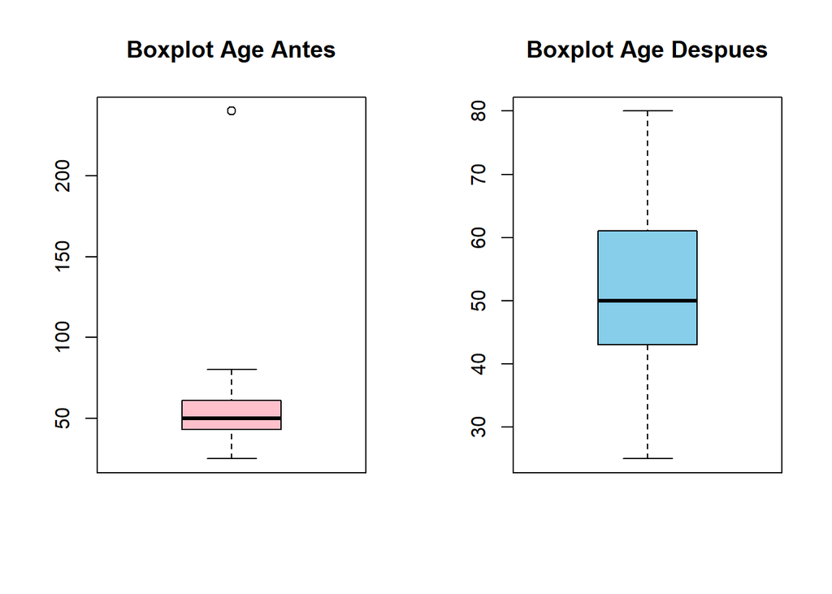

**Tabla 1. Indicadores descriptivos variable Age Antes y Después**

```
   Min. 1st Qu.  Median    Mean 3rd Qu.    Max.
  25.00   43.00   50.00   51.35   61.00  240.00
```

```
   Min. 1st Qu.  Median    Mean 3rd Qu.    Max.
  25.00   43.00   50.00   51.17   61.00   80.00
```

**Grafico 2. Comparativo variable marital_Divorced**

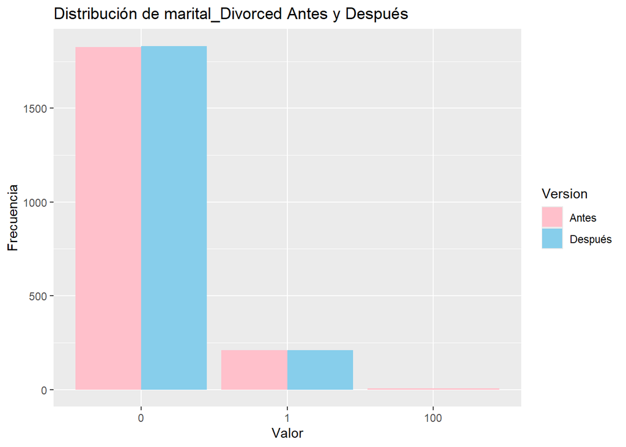

**Tabla 2. Indicadores descriptivos variable marital_Divorced Antes y Después**

```
    Min.  1st Qu.   Median     Mean  3rd Qu.     Max.
  0.0000   0.0000   0.0000   0.3964   0.0000 100.0000
```

```
   Min. 1st Qu.  Median    Mean 3rd Qu.    Max.
 0.0000  0.0000  0.0000  0.1024  0.0000  1.0000
```

## Identificación de datos faltantes

Para evaluar el mecanismo de generación de los datos faltantes se aplicó la prueba de Little (MCAR test). Para el análisis se consideraron las variables Income y MntWines, que son las únicas con datos faltantes en la base, junto con un conjunto reducido de variables que nos aportan contexto (Age, Kidhome, Teenhome, NumWebPurchases y NumWebVisitsMonth). Estas últimas se incluyeron con el fin de verificar si la ausencia de información en Income y MntWines podía estar asociada con características demográficas o de comportamiento de los clientes.

El resultado del test paramétrico (Hawkins) arrojó un p-valor extremadamente bajo, lo cual refleja que los datos no cumplen con el supuesto de normalidad multivariante y, por lo tanto, este resultado no es concluyente. Sin embargo, el test no paramétrico de homocedasticidad entregó un p-valor de 0.227 (>0.05), por lo que no se rechaza la hipótesis nula de MCAR.

Esto significa que no se encontró evidencia de un patrón sistemático en los datos faltantes. En consecuencia, los NA presentes en Income y MntWines pueden considerarse compatibles con un mecanismo MCAR, lo cual respalda el uso de métodos de imputación simples (como la imputación por la mediana) sin riesgo significativo de introducir sesgos en el análisis posterior.

**Grafico 3. Datos faltantes iniciales**

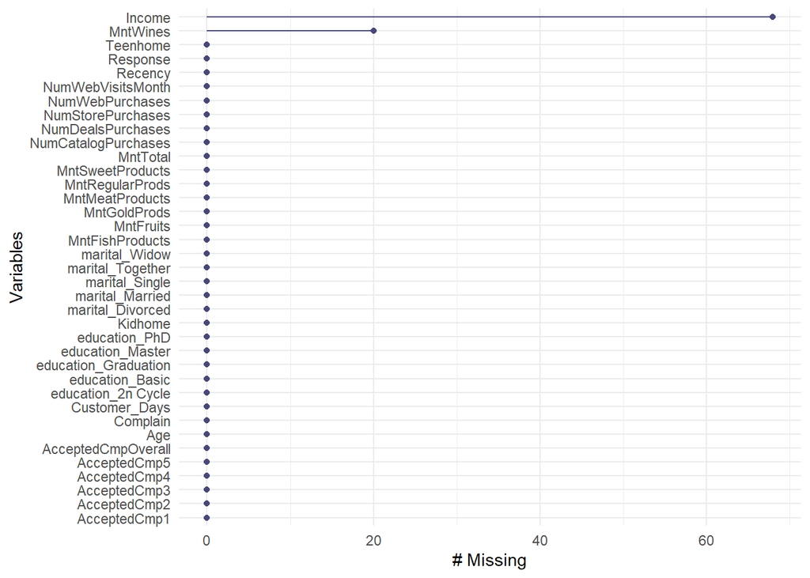

```
 Missings in variables:
 Variable Count
   Income    68
 MntWines    20
```

## Imputación de datos faltantes

En el análisis de los datos faltantes se encontró que solo Income y MntWines presentaban valores ausentes, representando menos del 5% de la base. Dado que ambas variables son numéricas y tienen distribuciones asimétricas con valores extremos, se imputaron los NA usando la mediana, al ser una medida más robusta que la media. Con esto se obtuvo la base data_SNA, ya sin valores faltantes y lista para el análisis descriptivo.

**Grafico 4. Comparativo variable Income**

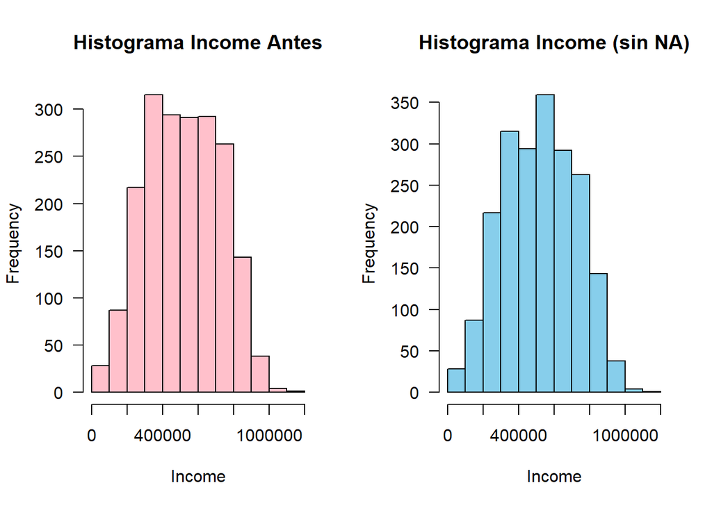

**Tabla 3. Indicadores descriptivos variable Income Antes y Despues**

```
   Min. 1st Qu.  Median    Mean 3rd Qu.    Max.    NA's
  17300  352460  514120  516809  681480 1137340      68
```

```
   Min. 1st Qu.  Median    Mean 3rd Qu.    Max.
  17300  357970  514120  516720  674320 1137340
```

**Grafico 5. Comparativo variable MntWines**

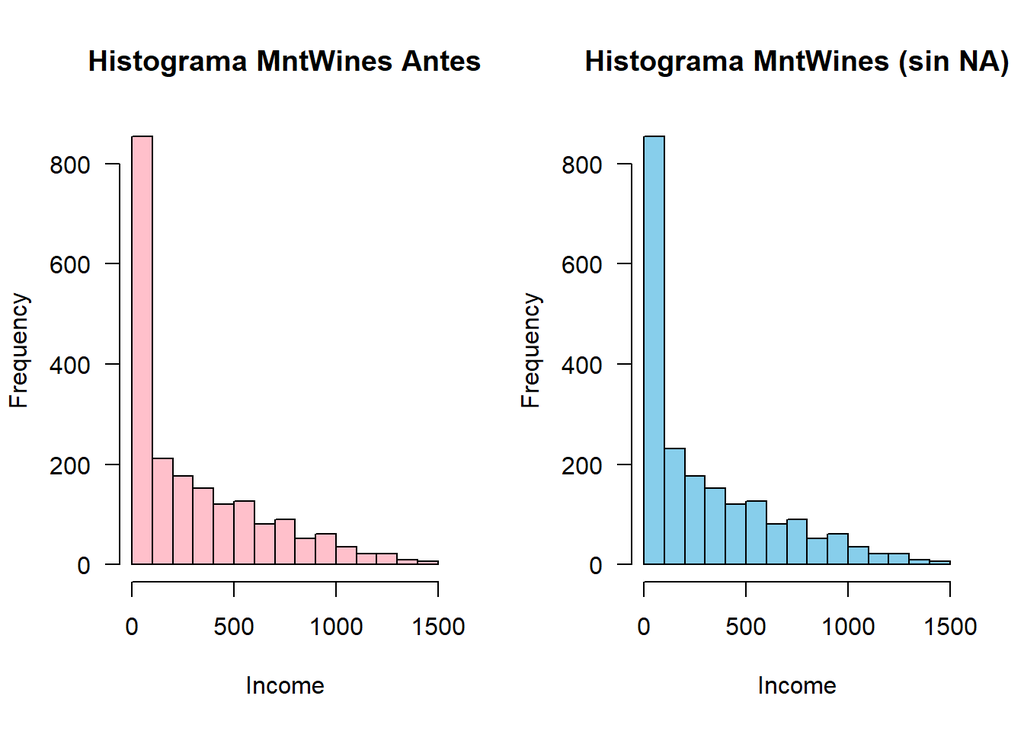

**Tabla 4. Indicadores descriptivos variable MntWines Antes y Despues**

```
   Min. 1st Qu.  Median    Mean 3rd Qu.    Max.    NA's
    0.0    24.0   174.0   301.5   499.0  1493.0      20
```

```
   Min. 1st Qu.  Median    Mean 3rd Qu.    Max.
    0.0    24.0   174.0   300.3   494.0  1493.0
```

# Resultados y discusión

### Income Vs MntTotal

Al analizar la relación entre Income y MntTotal mediante un diagrama de dispersión y el cálculo de coeficientes de correlación, se encontró una correlación positiva fuerte. El coeficiente de Pearson fue de 0.809, lo que indica una relación lineal considerable, mientras que el coeficiente de Spearman fue de 0.858, confirmando que la asociación se mantiene incluso frente a valores extremos. Estos resultados sugieren que los clientes con mayores ingresos tienden a realizar un mayor gasto total en productos.

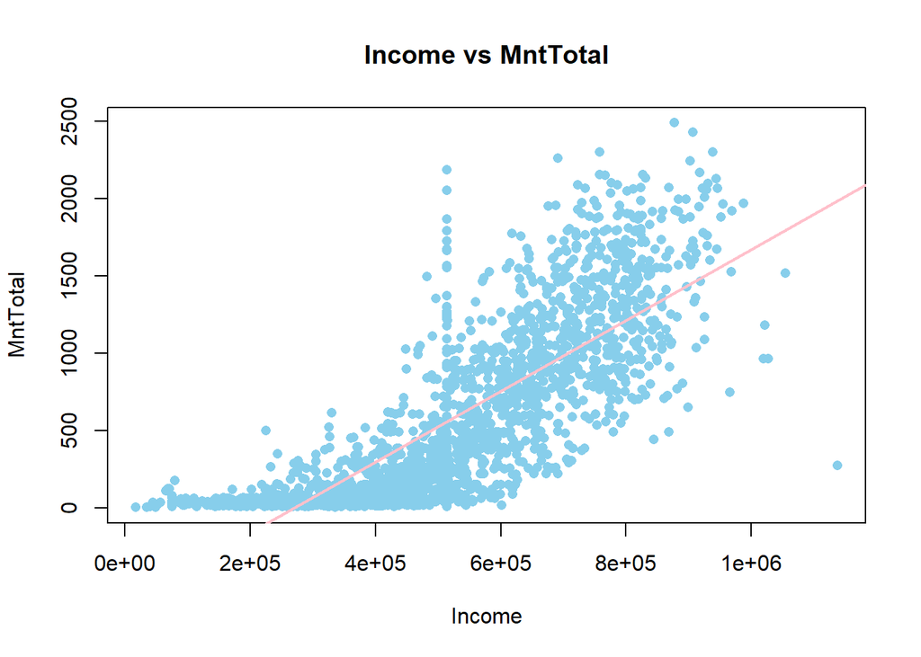

```
[1] 0.8090103
```

```
[1] 0.8582652
```

### Income Vs MntWines

En el análisis bivariado entre Income y MntWines se encontró una relación positiva. El coeficiente de correlación de Pearson fue de 0.698, lo que indica una asociación lineal moderada-alta, mientras que el coeficiente de Spearman alcanzó 0.822, reflejando una correlación fuerte al considerar el orden de los datos. Esto sugiere que, aunque existe dispersión en los valores de gasto, los clientes con mayores ingresos tienden de manera consistente a destinar más dinero a la compra de vinos.

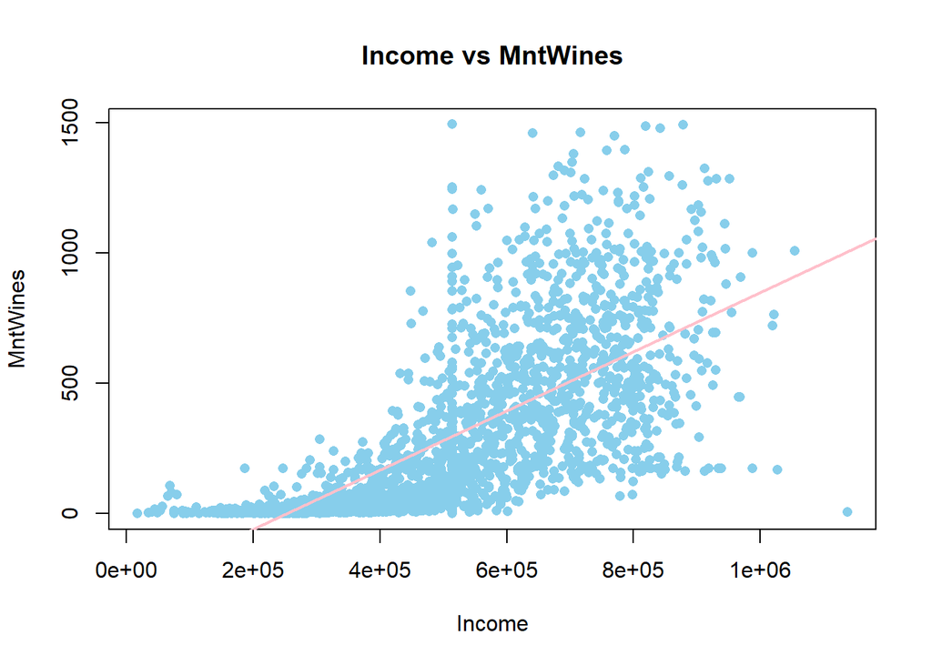

```
[1] 0.6984724
```

```
[1] 0.8219928
```

### Estado Civil vs Aceptación de campaña

Al analizar la aceptación de campañas según el estado civil, se observa que en todos los grupos predomina la no aceptación (entre un 75% y 80%). La proporción de clientes que aceptaron al menos una campaña se mantiene relativamente constante en los diferentes estados civiles, sin diferencias marcadas entre casados, solteros, divorciados, viudos o en unión. Esto sugiere que el estado civil no es un factor determinante en la respuesta a las campañas de marketing.

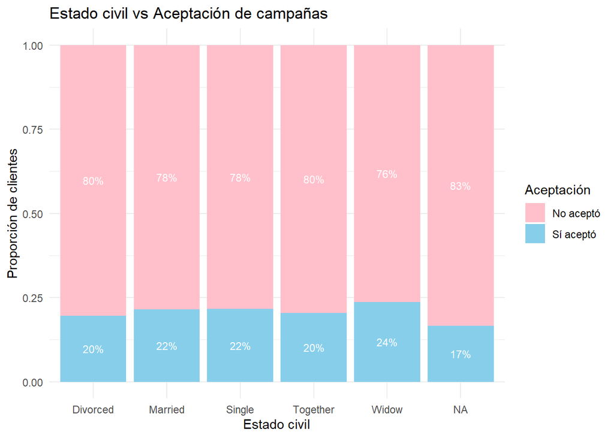

### Educacion vs Aceptación de campaña

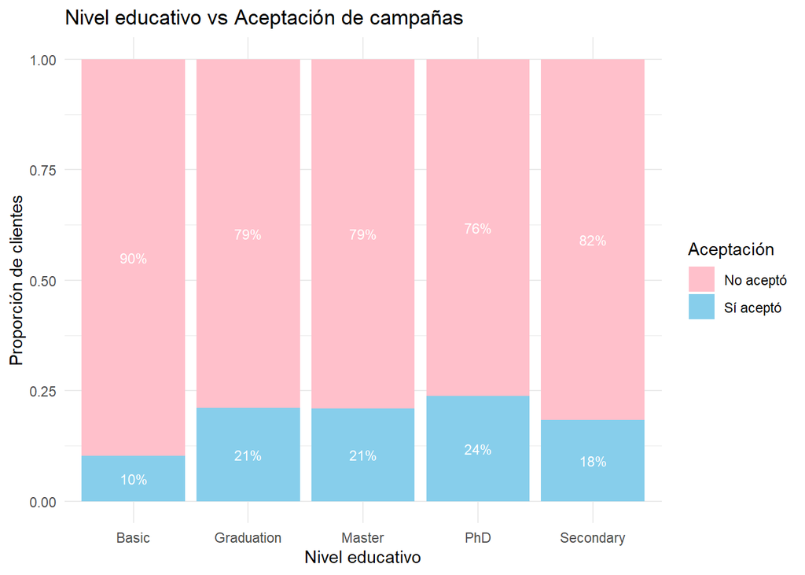

### Edad vs Aceptación de campaña

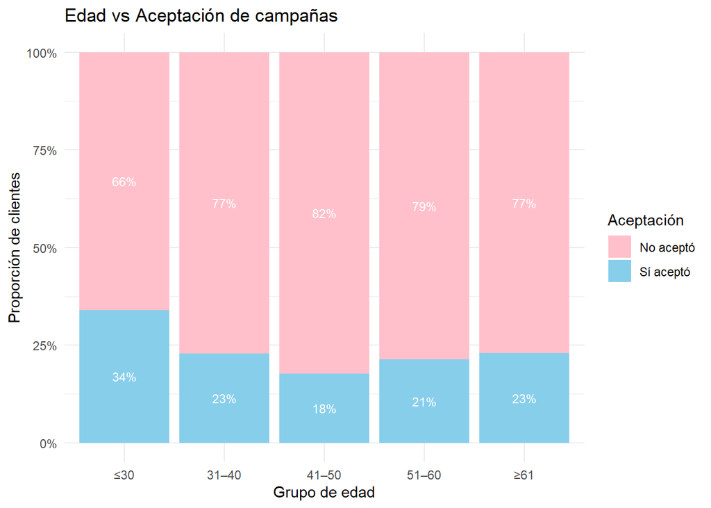

### Income vs Aceptación de campaña

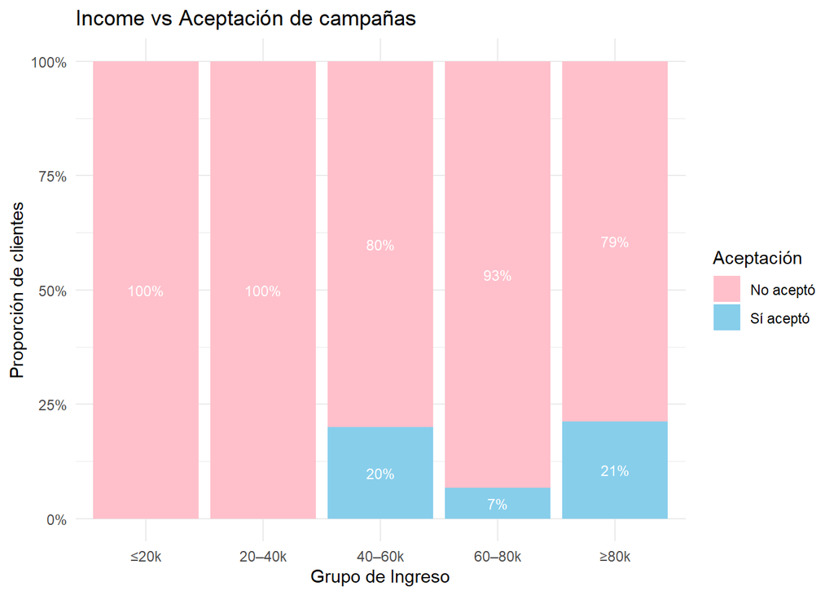

```
                                Df    Sum Sq   Mean Sq F value Pr(>F)
as.factor(AcceptedCmpOverall)    4 1.232e+13 3.079e+12   86.52 <2e-16 ***
Residuals                     2036 7.247e+13 3.559e+10
---
Signif. codes:  0 '***' 0.001 '**' 0.01 '*' 0.05 '.' 0.1 ' ' 1
```

### Gasto por producto vs Aceptación de campaña

Los resultados muestran que los clientes que aceptaron al menos una campaña presentan un gasto promedio superior en todos los productos comparados con quienes no aceptaron ninguna. En algunos casos, como vinos o productos premium, la diferencia supera el 100%, lo que significa que los clientes receptivos a las campañas llegan a gastar más del doble en estos artículos frente al resto de los clientes. Esto evidencia que la aceptación de campañas está estrechamente vinculada con un perfil de cliente de mayor valor, con mayor capacidad de gasto y mayor afinidad hacia productos de alto ticket.

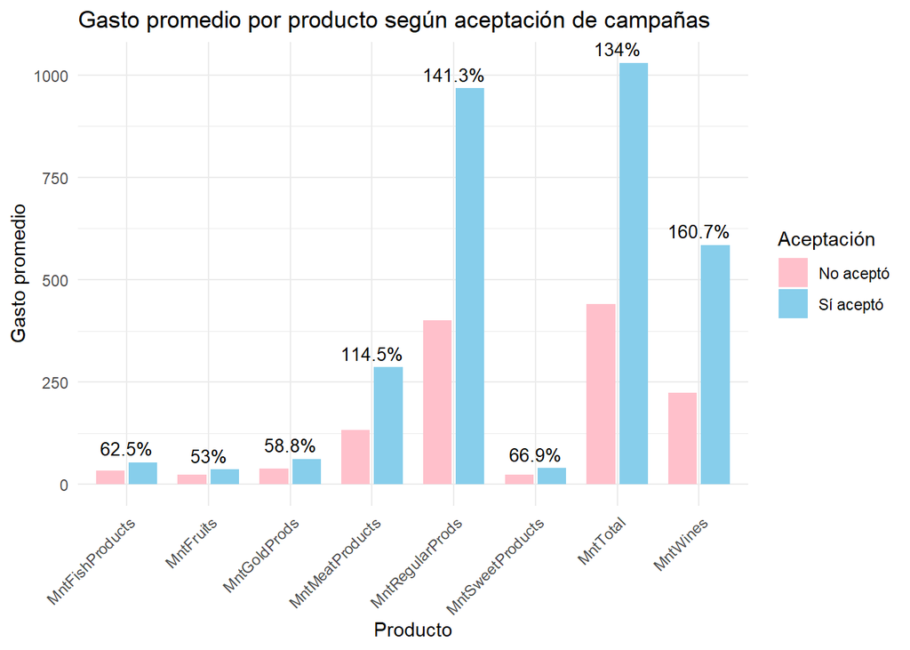

### Distribución de Compras/Visitas vs Aceptación de campaña

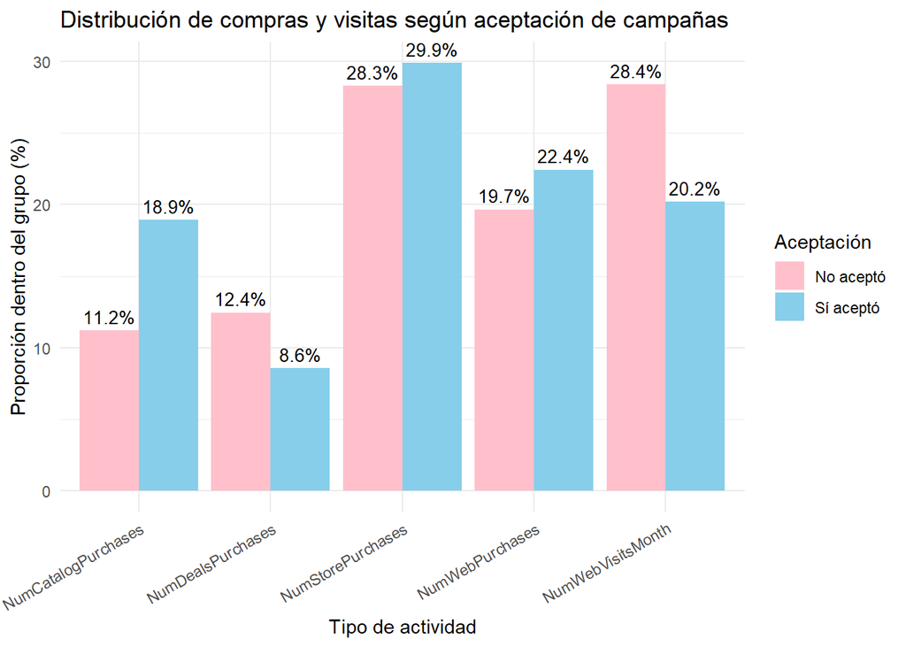

# Conclusiones

La depuración de la base permitió obtener 2.041 clientes únicos tras eliminar duplicados y corregir inconsistencias evidentes en Age y marital_Divorced. Los datos faltantes en Income y MntWines (<5%) se imputaron con la mediana tras confirmar un patrón MCAR, y los valores atípicos en ingresos, compras y gasto, aunque elevados, se consideraron plausibles y se mantuvieron para preservar la representatividad de clientes de alto valor.

# Referencias

Gobierno de España. (2021). Análisis exploratorio de datos (EDA). Portal de Datos Abiertos del Gobierno de España. https://datos.gob.es/sites/default/files/doc/file/analisis_exploratorio_de_datos_2021.pdf

U.S. Environmental Protection Agency. (n.d.). Exploratory data analysis. EPA. Retrieved October 30, 2024, from https://www.epa.gov/caddis/exploratory-data-analysis

Aggarwal, C. C. (2015). Data mining: The textbook. Springer. https://auladigital.javerianacali.edu.co/content/enforced/254856-ZOJV20241125001/DataMining_Aggarwal_2015.pdf?ou=303239

Centro Magis (2025). Material del curso Métodos y Simulación, versión 02-2025. Maestría en Ciencia de Datos, Pontificia Universidad Javeriana Cali, Facultad de Ingeniería.

# Anexos

**Tabla 5. Tabla descriptiva de variables**

| Variable | Descripcion | Clasificacion |
| --- | --- | --- |
| AcceptedCmp1 | 1 if customer accepted the offer in the 1st campaign, 0 otherwise | Cuantitativa discreta (binaria) |
| AcceptedCmp2 | 1 if customer accepted the offer in the 2nd campaign, 0 otherwise | Cuantitativa discreta (binaria) |
| AcceptedCmp3 | 1 if customer accepted the offer in the 3rd campaign, 0 otherwise | Cuantitativa discreta (binaria) |
| AcceptedCmp4 | 1 if customer accepted the offer in the 4th campaign, 0 otherwise | Cuantitativa discreta (binaria) |
| AcceptedCmp5 | 1 if customer accepted the offer in the 5th campaign, 0 otherwise | Cuantitativa discreta (binaria) |
| AcceptedCmpOverall | Overall number of accepted campaigns | Cuantitativa discreta |
| Response | 1 if customer accepted the offer in the last campaign, 0 otherwise | Cuantitativa discreta (binaria) |
| Complain | 1 if customer complained in the last 2 years | Cuantitativa discreta (binaria) |
| DtCustomer | Date of customer’s enrolment with the company | Fecha |
| Customer_Days | Number of days since registration as a customer | Cuantitativa discreta |
| Education | Customer’s level of education | Cualitativa ordinal |
| education_2n Cycle | Customer has secondary education | Cuantitativa discreta (binaria) |
| education_Basic | Customer has basic education | Cuantitativa discreta (binaria) |
| education_Graduation | Customer has a bachelor degree | Cuantitativa discreta (binaria) |
| education_Master | Customer has a masters degree | Cuantitativa discreta (binaria) |
| education_PhD | Customer has a PhD | Cuantitativa discreta (binaria) |
| Marital | Customer’s marital status | Cualitativa nominal |
| marital_Divorced | 1 if customer is divorced, 0 otherwise | Cuantitativa discreta (binaria) |
| marital_Married | 1 if customer is married, 0 otherwise | Cuantitativa discreta (binaria) |
| marital_Single | 1 if customer is single, 0 otherwise | Cuantitativa discreta (binaria) |
| marital_Together | 1 if customer is in relationship, 0 otherwise | Cuantitativa discreta (binaria) |
| marital_Widow | 1 if customer is a widow/widower, 0 otherwise | Cuantitativa discreta (binaria) |
| Kidhome | Number of small children in customer’s household | Cuantitativa discreta |
| Teenhome | Number of teenagers in customer’s household | Cuantitativa discreta |
| Income | Customer’s yearly household income | Cuantitativa continua |
| MntFishProducts | Amount spent on fish products in the last 2 years | Cuantitativa continua |
| MntMeatProducts | Amount spent on meat products in the last 2 years | Cuantitativa continua |
| MntFruits | Amount spent on fruit products in the last 2 years | Cuantitativa continua |
| MntSweetProducts | Amount spent on sweet products in the last 2 years | Cuantitativa continua |
| MntWines | Amount spent on wine products in the last 2 years | Cuantitativa continua |
| MntGoldProds | Amount spent on gold products in the last 2 years | Cuantitativa continua |
| NumDealsPurchases | Number of purchases made with discount | Cuantitativa discreta |
| NumCatalogPurchases | Number of purchases made using catalogue | Cuantitativa discreta |
| NumStorePurchases | Number of purchases made directly in stores | Cuantitativa discreta |
| NumWebPurchases | Number of purchases made through company’s website | Cuantitativa discreta |
| NumWebVisitsMonth | Number of visits to company’s website in the last month | Cuantitativa discreta |
| Recency | Number of days since the last purchase | Cuantitativa discreta |
| Age | Age of customer | Cuantitativa discreta |
| MntTotal | Total amount spent on all the products | Cuantitativa continua |
| MntRegularProds | Total amount spent on regular products | Cuantitativa continua |

**Tabla 6. Chequeo variables binarias**

```
          variable n_inconsistencias valores_detectados
1 marital_Divorced                 6                100
```

```
  fila         variable valor
1   70 marital_Divorced   100
2  272 marital_Divorced   100
3  670 marital_Divorced   100
4 1068 marital_Divorced   100
5 1524 marital_Divorced   100
6 1998 marital_Divorced   100
```

**Tabla 7. Chequeo variables categoricas**

```
            variable n_inconsistencias valores_detectados
1 AcceptedCmpOverall                 0                  —
2            Kidhome                 0                  —
3           Teenhome                 0                  —
```

**Tabla 8. Chequeo variables cuantitativas**

```
              variable n_outliers pct_outliers
7     MntSweetProducts        223        10.93
3            MntFruits        222        10.88
2      MntFishProducts        204        10.00
4         MntGoldProds        186         9.11
5      MntMeatProducts        170         8.33
11   NumDealsPurchases         74         3.63
9             MntWines         35         1.71
10 NumCatalogPurchases         19         0.93
13   NumWebVisitsMonth          8         0.39
6      MntRegularProds          4         0.20
8             MntTotal          3         0.15
12     NumWebPurchases          3         0.15
1                  Age          2         0.10
```

```
     fila            variable valor      motivo
1      44                 Age   240 outlier IQR
2    1113                 Age   240 outlier IQR
3      21   NumDealsPurchases    15 outlier IQR
4      24   NumDealsPurchases     7 outlier IQR
5      46   NumDealsPurchases     9 outlier IQR
6      51   NumDealsPurchases     7 outlier IQR
7      65   NumDealsPurchases     7 outlier IQR
8     137   NumDealsPurchases     7 outlier IQR
9     198   NumDealsPurchases     8 outlier IQR
10    199   NumDealsPurchases    10 outlier IQR
11    216   NumDealsPurchases     9 outlier IQR
12    229   NumDealsPurchases     7 outlier IQR
13    270   NumDealsPurchases    13 outlier IQR
14    343   NumDealsPurchases     7 outlier IQR
```

[output cut: 1139 more lines]

**Tabla 9. Indicadores descriptivos variables cuantitativas (con inconsistencias)**

```
Descriptive Statistics
df_num
N: 2041

                        Age   Customer_Days       Income   MntFishProducts   MntFruits
----------------- --------- --------------- ------------ ----------------- -----------
             Mean     51.35         2511.35    516809.10             37.58       26.34
          Std.Dev     13.04          202.60    207352.46             54.81       39.80
              Min     25.00         2159.00     17300.00              0.00        0.00
               Q1     43.00         2337.00    352460.00              3.00        2.00
           Median     50.00         2510.00    514120.00             12.00        8.00
               Q3     61.00         2688.00    681480.00             50.00       33.00
              Max    240.00         2858.00   1137340.00            259.00      199.00
              MAD     13.34          260.94    244288.00             17.79       11.86
              IQR     18.00          351.00    329020.00             47.00       31.00
               CV      0.25            0.08         0.40              1.46        1.51
         Skewness      3.00            0.00         0.01              1.92        2.11
      SE.Skewness      0.05            0.05         0.06              0.05        0.05
         Kurtosis     41.24           -1.21        -0.83              3.06        4.11
          N.Valid   2041.00         2041.00      1973.00           2041.00     2041.00
                N   2041.00         2041.00      2041.00           2041.00     2041.00
        Pct.Valid    100.00          100.00        96.67            100.00      100.00

Table: Table continues below



                    MntGoldProds   MntMeatProducts   MntRegularProds   MntSweetProducts   MntTotal
----------------- -------------- ----------------- ----------------- ------------------ ----------
             Mean          43.88            165.99            520.59              27.34     564.48
          Std.Dev          51.75            219.77            555.88              41.64     577.84
              Min           0.00              0.00           -283.00               0.00       4.00
               Q1           9.00             16.00             42.00               1.00      55.00
           Median          24.00             68.00            288.00               8.00     343.00
               Q3          56.00            230.00            886.00              34.00     965.00
              Max         321.00           1725.00           2458.00             262.00    2491.00
              MAD          28.17             88.96            400.30              11.86     459.61
              IQR          47.00            214.00            844.00              33.00     910.00
               CV           1.18              1.32              1.07               1.52       1.02
         Skewness           1.85              1.82              0.98               2.09       0.92
```

[output cut: 36 more lines]

```
          Std.Dev              2.75                2.43     28.94
              Min              0.00                0.00      0.00
               Q1              2.00                3.00     24.00
           Median              4.00                6.00     49.00
               Q3              6.00                7.00     74.00
              Max             27.00               20.00     99.00
              MAD              2.97                2.97     37.06
              IQR              4.00                4.00     50.00
               CV              0.67                0.45      0.59
         Skewness              1.23                0.27      0.00
      SE.Skewness              0.05                0.05      0.05
         Kurtosis              4.32                2.05     -1.20
          N.Valid           2041.00             2041.00   2041.00
                N           2041.00             2041.00   2041.00
        Pct.Valid            100.00              100.00    100.00
```

**Grafico 6. Boxplot de variables cuantitativas (con inconsistencias)**

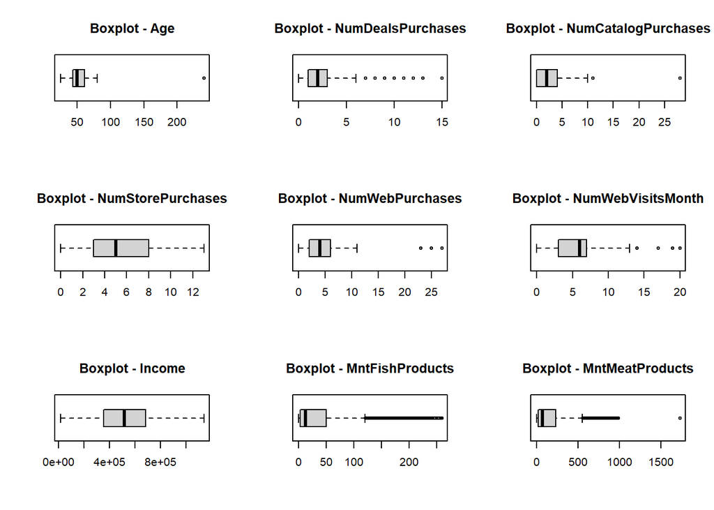

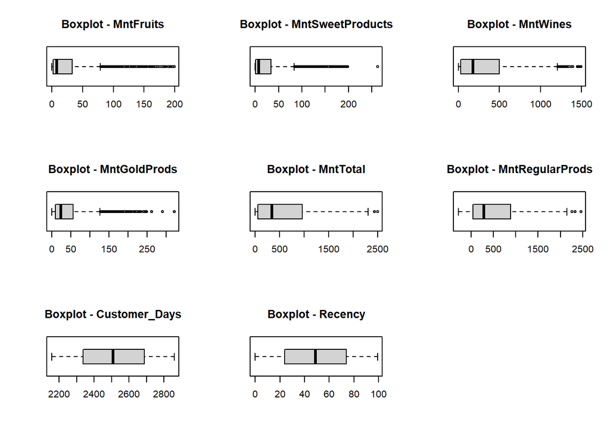

**Grafico 7. Porcentaje Datos Faltantes iniciales**

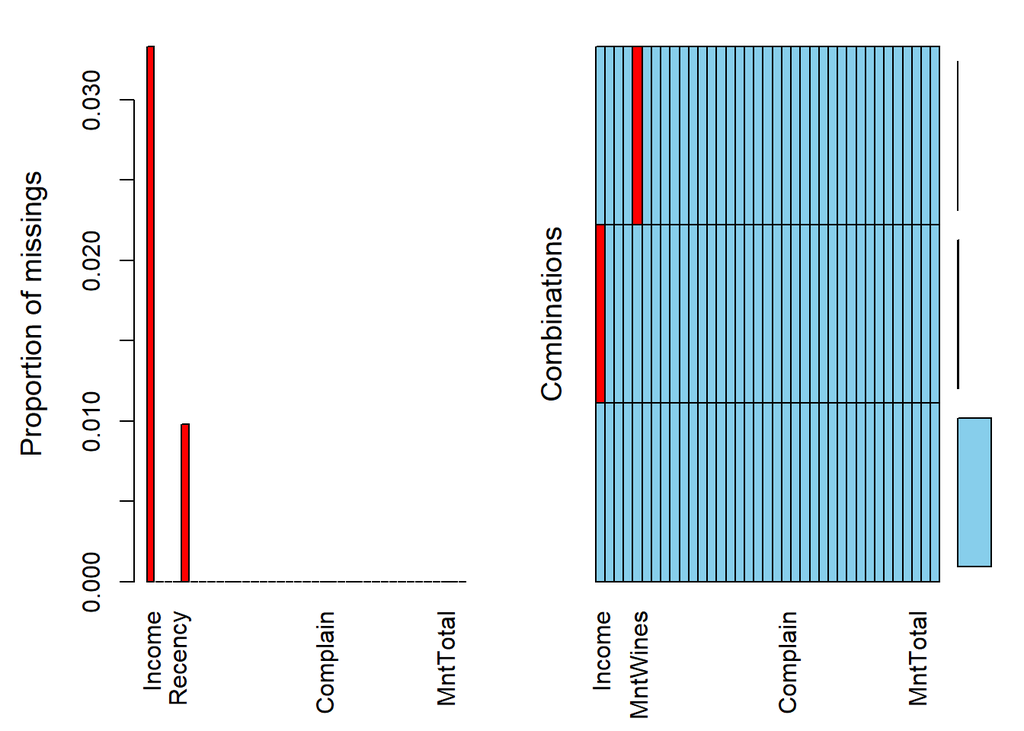

**Grafico 8. Mapa de calor simple de faltantes**

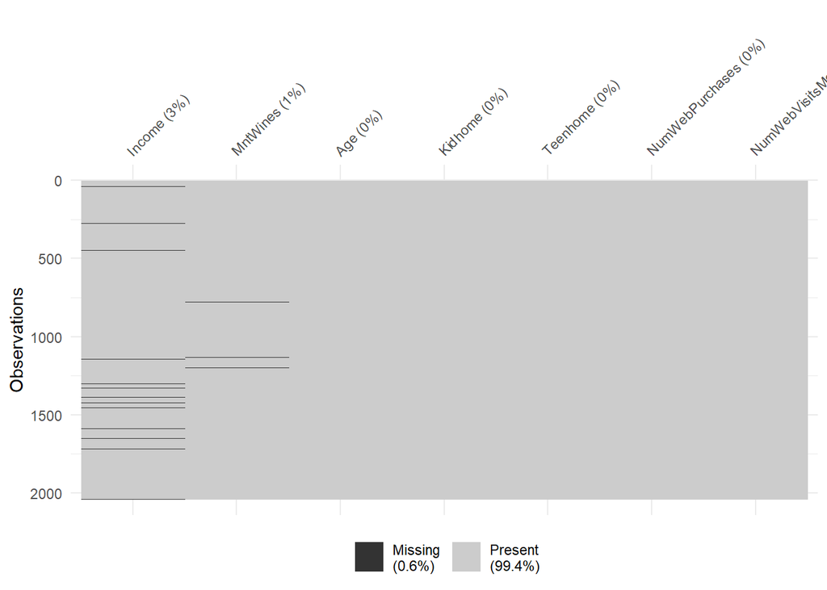

**Grafico 9. Porcentaje Datos faltantes Ajustados**

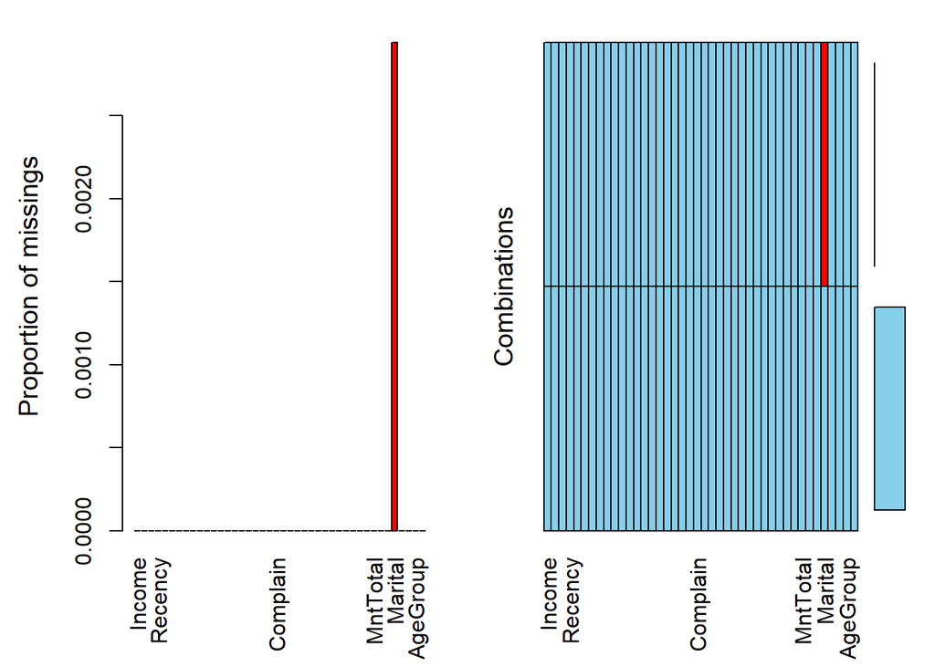

## Analisis descriptivo post-procesamiento

**Grafico 10. Estado Civil de los clientes**

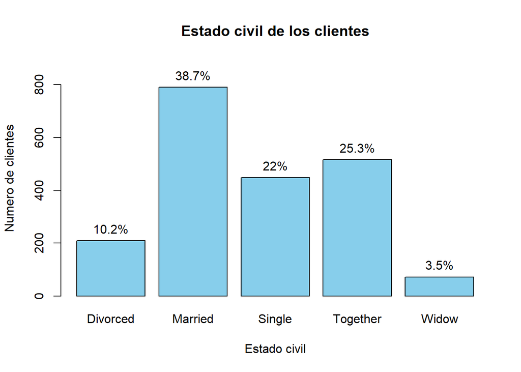

**Grafico 11. Nivel educativo de los clientes**

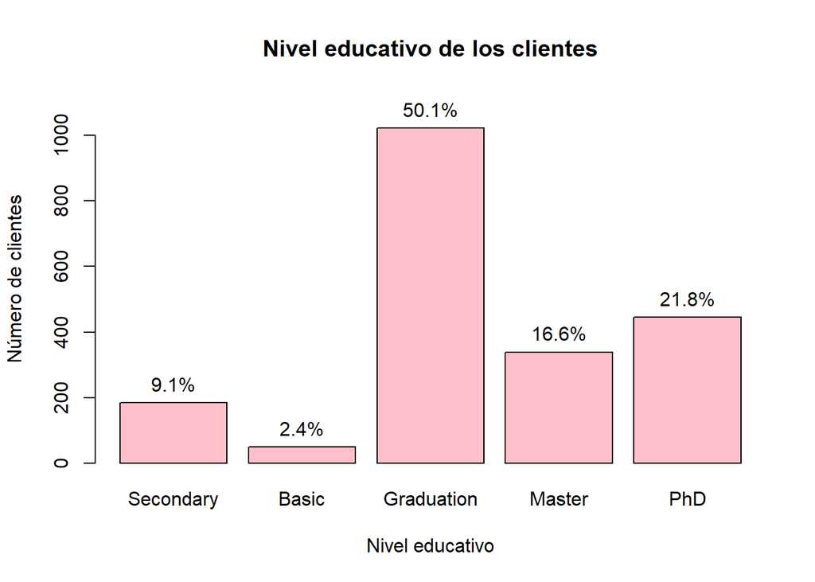

**Grafico 12. Distribución de gastos**

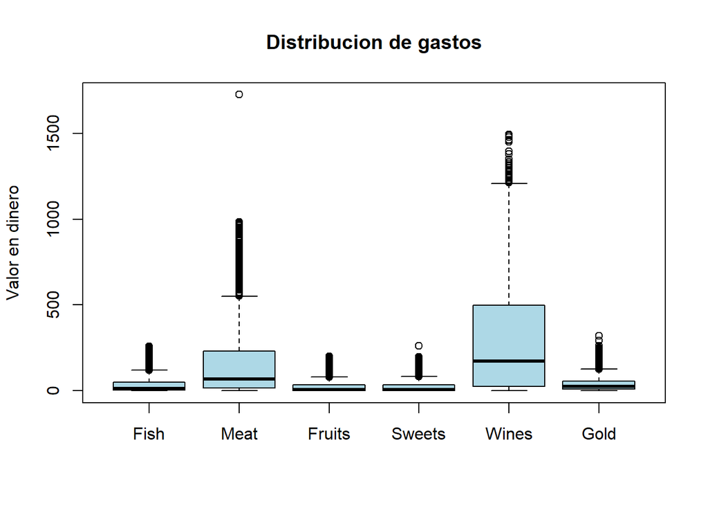

**Grafico 13. Distribución de compras y visitas**

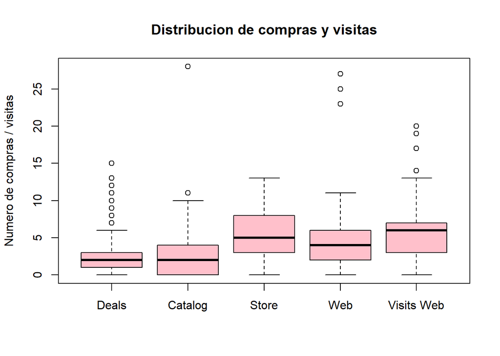

**Grafico 14. Aceptación de campañas**

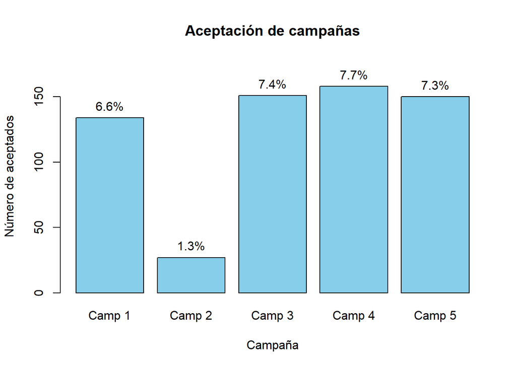